# Reglas de Asociación

# 3 Preparación de los datos, creación de un dataset transaccional

```r
#Split en grupos

data_list = split(datos2$Itemname,datos2$BillNo)

#Transformación a un dataset transaccional
data_trx = as(data_list,"transactions")
```

## 3.1 Inspección del dataset, 3 primeras transacciones

```r
inspect(head(data_trx[1:3]))
```

```
##     items                                  transactionID
## [1] {CREAM CUPID HEARTS COAT HANGER,
##      GLASS STAR FROSTED T-LIGHT HOLDER,
##      KNITTED UNION FLAG HOT WATER BOTTLE,
##      RED WOOLLY HOTTIE WHITE HEART.,
##      SET 7 BABUSHKA NESTING BOXES,
##      WHITE HANGING HEART T-LIGHT HOLDER,
##      WHITE METAL LANTERN}                         536365
## [2] {HAND WARMER RED POLKA DOT,
##      HAND WARMER UNION JACK}                      536366
## [3] {ASSORTED COLOUR BIRD ORNAMENT,
##      BOX OF 6 ASSORTED COLOUR TEASPOONS,
##      BOX OF VINTAGE ALPHABET BLOCKS,
##      BOX OF VINTAGE JIGSAW BLOCKS,
##      DOORMAT NEW ENGLAND,
##      FELTCRAFT PRINCESS CHARLOTTE DOLL,
##      HOME BUILDING BLOCK WORD,
##      IVORY KNITTED MUG COSY,
##      LOVE BUILDING BLOCK WORD,
##      POPPY'S PLAYHOUSE BEDROOM,
##      POPPY'S PLAYHOUSE KITCHEN,
##      RECIPE BOX WITH METAL HEART}                 536367
```

# 4 Análisis de los productos más vendidos teniendo en cuenta cada compra o transacción

## 4.1 Top 10 de productos más vendidos en el dataset transaccional

Como vemos este datos varía en comparación con el gráfico anterior debido a que no se tiene en cuenta cuando se comprar varias unidades del mismo artículo en una transacción, solo se tiene en cuente una unidad.

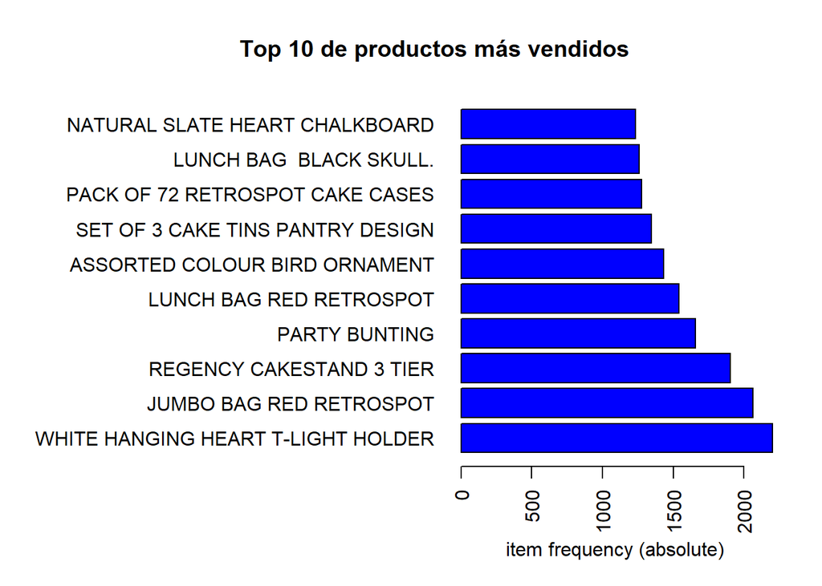

```r
itemFrequencyPlot(data_trx, cex.names =graphics::par("cex.axis"), topN = 10, col = "blue", horiz = TRUE, type ="absolute")
title("Top 10 de productos más vendidos")
```

## 4.2 Tamaño de las transacciones

```r
# Resumen
size_trans <- data.frame(tamanho = size(data_trx))
summary(size_trans)
```

```
##     tamanho
##  Min.   :   1.00
##  1st Qu.:   5.00
##  Median :  15.00
##  Mean   :  25.23
##  3rd Qu.:  28.00
##  Max.   :1108.00
```

```r
# Valor máximo
print(paste("Valor máximo:", max(size_trans)))
```

```
## [1] "Valor máximo: 1108"
```

```r
# Valor mínimo
print(paste("Valor máximo:", min(size_trans)))
```

```
## [1] "Valor máximo: 1"
```

## 4.3 Representación gráfica del tamaño de cada transacción

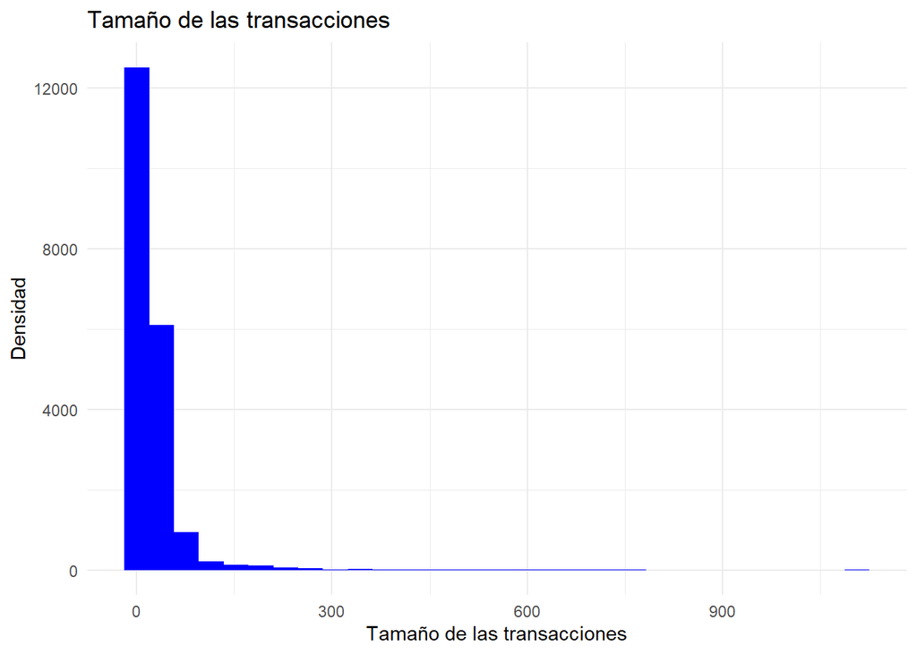

```r
# Distribucion del tamanho de todas las transacciones
ggplot(size_trans, aes(x = tamanho)) +
  geom_histogram(fill = "blue") +
  labs(x = "Tamaño de las transacciones", y = "Densidad", title = "Tamaño de las transacciones") +
  theme_minimal()
```

## Tamaño de las transacciones por cuantiles

```r
summary(size_trans)
```

```
##     tamanho
##  Min.   :   1.00
##  1st Qu.:   5.00
##  Median :  15.00
##  Mean   :  25.23
##  3rd Qu.:  28.00
##  Max.   :1108.00
```

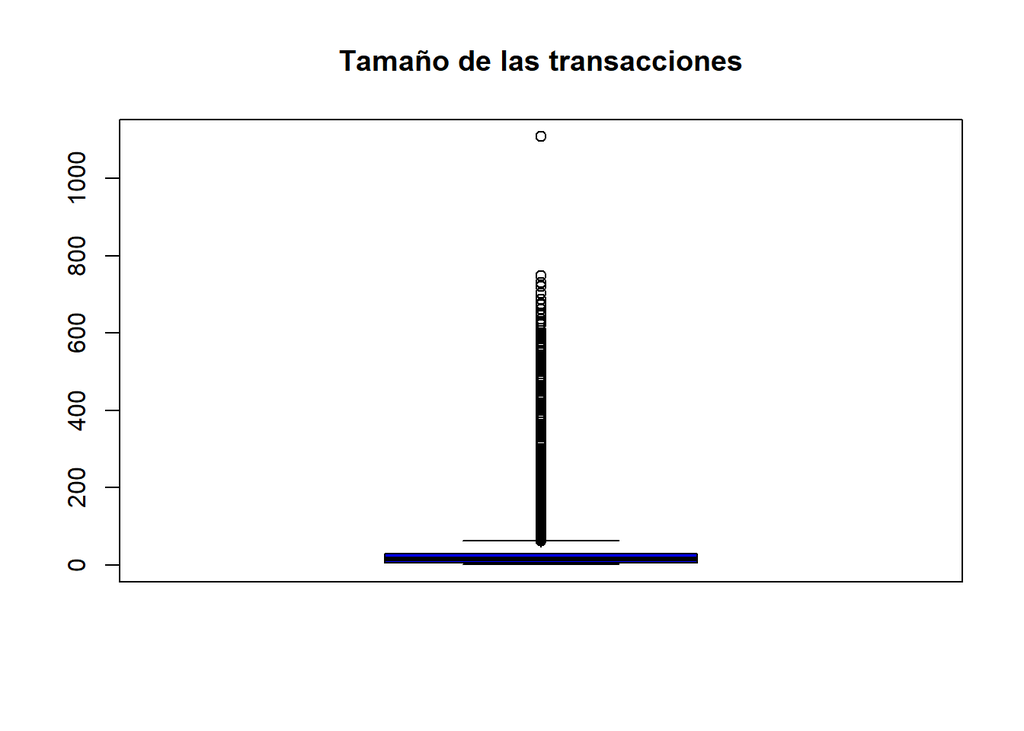

```r
boxplot(size_trans$tamanho,col="blue", main = "Tamaño de las transacciones")
```

# 5 Obtención de las Reglas de asociación con el algoritmo Apriori

## 5.1 Establecemos el soporte y la confianza

El valor de soporte obtenido nos da problemas a realizar el cálculo por lo que elegimos un soporte mayor, de 0.01, y una confianza de al menos un 90% para obtener unas reglas fiables.

```r
# Umbral de soporte
soporte <- 25/dim(data_trx)[1]
soporte
```

```
## [1] 0.001237134
```

## 5.2 Tamaño del dataset

Para reducir el tamaño del dataset, eliminamos las transacciones en las que sólo aparece un elemento, de esta manera reducimos el tiempo de cálculo del algoritmo, eliminando 2239 filas

```r
transacciones <- data_trx[size_trans > 1]
dim(data_trx)
```

```
## [1] 20208  4185
```

```r
dim(transacciones)
```

```
## [1] 17969  4185
```

Utilizamos un soporte de 0.01 y una confianza del 90%

```r
articulos_frecuentes <- apriori(data = transacciones,
                  parameter = list(support = 0.01,
                                   confidence = 0.90,
                                   target = "frequent itemsets"),
                  control = list(verbose = FALSE))
```

## 5.3 Artículos frecuentes

```r
print(paste("articulos frecuentes:", length(articulos_frecuentes)))
```

```
## [1] "articulos frecuentes: 2475"
```

```r
summary(articulos_frecuentes)
```

```
## set of 2475 itemsets
##
## most frequent items:
## JUMBO BAG RED RETROSPOT LUNCH BAG RED RETROSPOT          DOTCOM POSTAGE
##                     236                     141                     122
##  JUMBO STORAGE BAG SUKI JUMBO BAG PINK POLKADOT                 (Other)
##                     119                     102                    3813
##
## element (itemset/transaction) length distribution:sizes
##    1    2    3    4    5
##  888 1163  378   45    1
##
##    Min. 1st Qu.  Median    Mean 3rd Qu.    Max.
##   1.000   1.000   2.000   1.832   2.000   5.000
##
## summary of quality measures:
##     support            count
##  Min.   :0.01002   Min.   : 180.0
##  1st Qu.:0.01107   1st Qu.: 199.0
##  Median :0.01297   Median : 233.0
##  Mean   :0.01638   Mean   : 294.3
##  3rd Qu.:0.01747   3rd Qu.: 314.0
##  Max.   :0.12154   Max.   :2184.0
##
## includes transaction ID lists: FALSE
##
## mining info:
##           data ntransactions support confidence
##  transacciones         17969    0.01          1
##                                                                                                                                              call
##  apriori(data = transacciones, parameter = list(support = 0.01, confidence = 0.9, target = "frequent itemsets"), control = list(verbose = FALSE))
```

## 5.4 Reglas de asociación

```r
reglas <- apriori(data = transacciones,
                  parameter = list(support = 0.01,
                                   confidence = 0.90,
                                   target = "rules"),
                  control = list(verbose = FALSE))
```

## 5.5 Reglas generadas

```r
print(paste("Reglas generadas:", length(reglas)))
```

```
## [1] "Reglas generadas: 70"
```